# Exploratory analysis of context: KL Divergence

Morgan Moyer

May 18, 2021

```
## [1] 273976
```

```
## [1] 273976
```

# Calculate KL-Divergence

Compare to the uniform distribution.

KLD(P || Q) = sum x in X: (P(x) * log2(P(x)/Q(x)))

## Plot the KLD between context and no context

### Overall

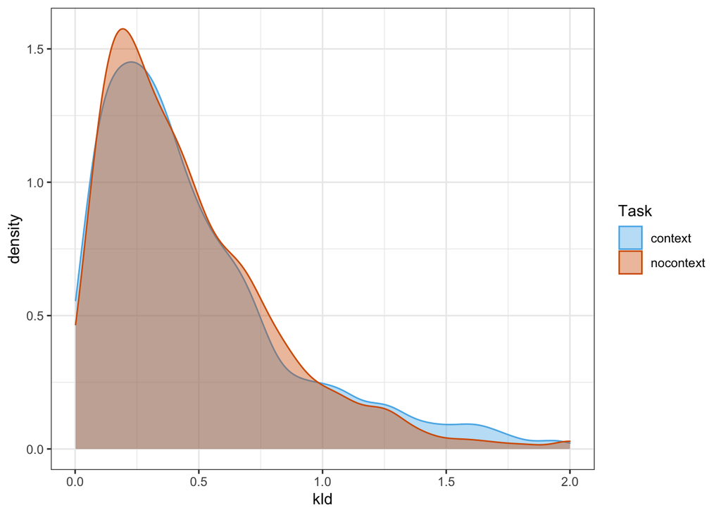

### Factors

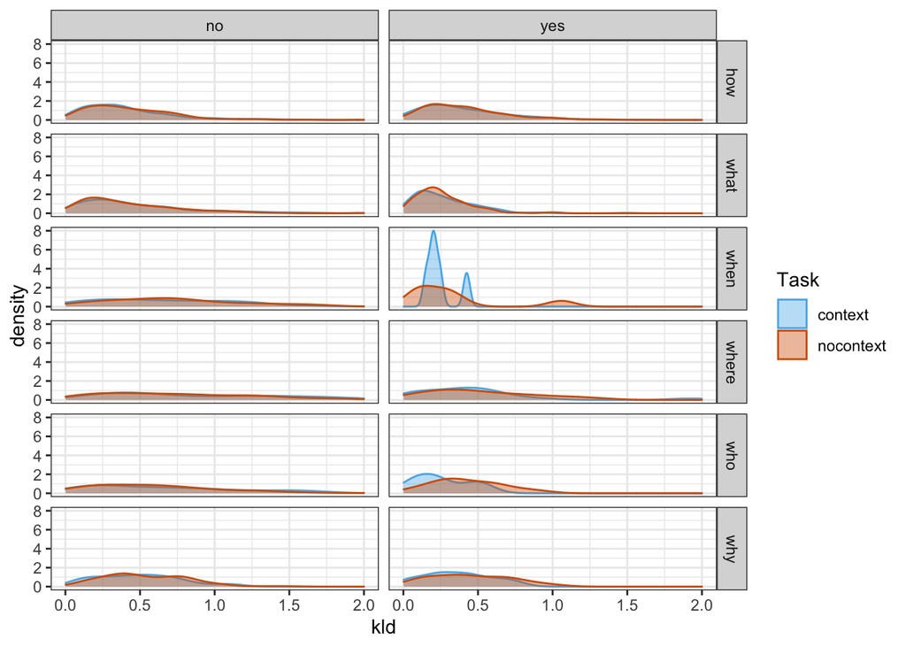

## Look at kld by item

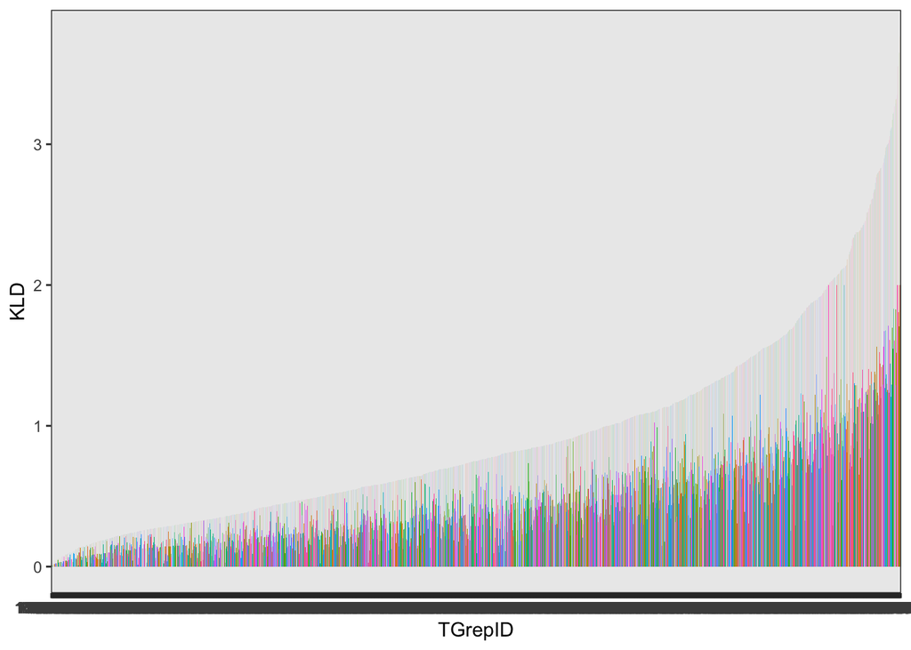

### Example

```
## # A tibble: 8 x 4
## # Groups:   Sentence, Task [2]
##   Sentence                                        Task    paraphrase mean_rating
##   <chr>                                           <chr>   <chr>            <dbl>
## 1 i think, 0 especially in the younger years you… context a               0.105
## 2 i think, 0 especially in the younger years you… context every           0.205
## 3 i think, 0 especially in the younger years you… context other           0.243
## 4 i think, 0 especially in the younger years you… context the             0.447
## 5 i think, 0 especially in the younger years you… nocont… a               0.444
## 6 i think, 0 especially in the younger years you… nocont… every           0.0959
## 7 i think, 0 especially in the younger years you… nocont… other           0.124
## 8 i think, 0 especially in the younger years you… nocont… the             0.336
```

# Graph by-item absolute differences in KLD between Task

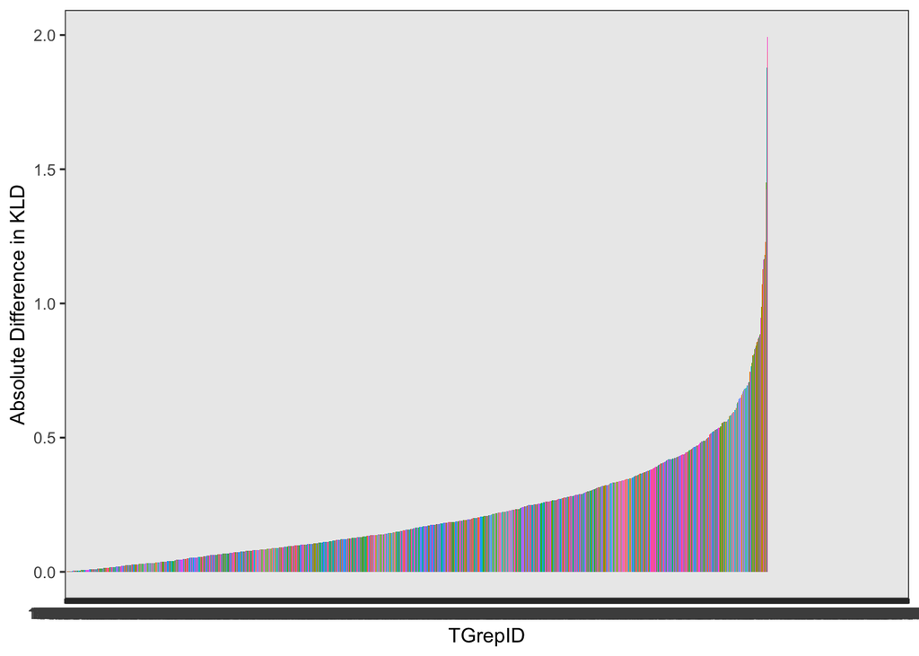

## Examples with the biggest difference

- 132917:4: what do you have *t*-1 now?
- the –> a/every

```
## # A tibble: 8 x 4
## # Groups:   Sentence, Task [2]
##   Sentence                    Task      paraphrase mean_rating
##   <chr>                       <chr>     <chr>            <dbl>
## 1 what do you have *t*-1 now? context   a             2.28e- 2
## 2 what do you have *t*-1 now? context   every         1.28e- 2
## 3 what do you have *t*-1 now? context   other         6.17e-18
## 4 what do you have *t*-1 now? context   the           9.64e- 1
## 5 what do you have *t*-1 now? nocontext a             2.41e- 1
## 6 what do you have *t*-1 now? nocontext every         2.54e- 1
## 7 what do you have *t*-1 now? nocontext other         4.28e- 2
## 8 what do you have *t*-1 now? nocontext the           4.62e- 1
```

- 89239:4: what was the last one *t*-1?
- the –> a/other

```
## # A tibble: 8 x 4
## # Groups:   Sentence, Task [2]
##   Sentence                     Task      paraphrase mean_rating
##   <chr>                        <chr>     <chr>            <dbl>
## 1 what was the last one *t*-1? context   a              0.00313
## 2 what was the last one *t*-1? context   every          0
## 3 what was the last one *t*-1? context   other          0
## 4 what was the last one *t*-1? context   the            0.997
## 5 what was the last one *t*-1? nocontext a              0.142
## 6 what was the last one *t*-1? nocontext every          0.0500
## 7 what was the last one *t*-1? nocontext other          0.165
## 8 what was the last one *t*-1? nocontext the            0.643
```

(weird context) * 11053:4: where do you live *t*-1? - the –> a/other

```
## # A tibble: 8 x 4
## # Groups:   Sentence, Task [2]
##   Sentence                 Task      paraphrase mean_rating
##   <chr>                    <chr>     <chr>            <dbl>
## 1 where do you live *t*-1? context   a                0
## 2 where do you live *t*-1? context   every            0
## 3 where do you live *t*-1? context   other            0.006
## 4 where do you live *t*-1? context   the              0.994
## 5 where do you live *t*-1? nocontext a                0.129
## 6 where do you live *t*-1? nocontext every            0.038
## 7 where do you live *t*-1? nocontext other            0.122
## 8 where do you live *t*-1? nocontext the              0.71
```

- 126136:4: how did radio shack work *t*-1?
- the –> a

```
## # A tibble: 8 x 4
## # Groups:   Sentence, Task [2]
##   Sentence                        Task      paraphrase mean_rating
##   <chr>                           <chr>     <chr>            <dbl>
## 1 how did radio shack work *t*-1? context   a               0.0333
## 2 how did radio shack work *t*-1? context   every           0.0783
## 3 how did radio shack work *t*-1? context   other           0.0189
## 4 how did radio shack work *t*-1? context   the             0.869
## 5 how did radio shack work *t*-1? nocontext a               0.263
## 6 how did radio shack work *t*-1? nocontext every           0.181
## 7 how did radio shack work *t*-1? nocontext other           0.168
## 8 how did radio shack work *t*-1? nocontext the             0.388
```

- 49447:4: what did you have *t*-1 before you bought that.
- the –> a

```
## # A tibble: 8 x 4
## # Groups:   Sentence, Task [2]
##   Sentence                                       Task     paraphrase mean_rating
##   <chr>                                          <chr>    <chr>            <dbl>
## 1 what did you have *t*-1 before you bought tha… context  a               0.0688
## 2 what did you have *t*-1 before you bought tha… context  every           0.0338
## 3 what did you have *t*-1 before you bought tha… context  other           0
## 4 what did you have *t*-1 before you bought tha… context  the             0.898
## 5 what did you have *t*-1 before you bought tha… noconte… a               0.290
## 6 what did you have *t*-1 before you bought tha… noconte… every           0.0729
## 7 what did you have *t*-1 before you bought tha… noconte… other           0.172
## 8 what did you have *t*-1 before you bought tha… noconte… the             0.465
```

## Embedded question:

- 13656:19: uh, i have wondered why they allowed, or let, you know, both the father and mother go *t*-1, uh,
- more even –> strongly the

```
## # A tibble: 8 x 4
## # Groups:   Sentence, Task [2]
##   Sentence                                        Task    paraphrase mean_rating
##   <chr>                                           <chr>   <chr>            <dbl>
## 1 uh, i have wondered why they allowed, or let, … context a               0.095
## 2 uh, i have wondered why they allowed, or let, … context every           0.221
## 3 uh, i have wondered why they allowed, or let, … context other           0.0746
## 4 uh, i have wondered why they allowed, or let, … context the             0.609
## 5 uh, i have wondered why they allowed, or let, … nocont… a               0.0518
## 6 uh, i have wondered why they allowed, or let, … nocont… every           0.0176
## 7 uh, i have wondered why they allowed, or let, … nocont… other           0.0112
## 8 uh, i have wondered why they allowed, or let, … nocont… the             0.919
```

- 58758:18: and my mother taught me how * to make it *t*-1.
- the –> a

```
## # A tibble: 8 x 4
## # Groups:   Sentence, Task [2]
##   Sentence                                       Task     paraphrase mean_rating
##   <chr>                                          <chr>    <chr>            <dbl>
## 1 and my mother taught me how * to make it *t*-… context  a             0.0597
## 2 and my mother taught me how * to make it *t*-… context  every         0.00172
## 3 and my mother taught me how * to make it *t*-… context  other         0.00655
## 4 and my mother taught me how * to make it *t*-… context  the           0.932
## 5 and my mother taught me how * to make it *t*-… noconte… a             0.269
## 6 and my mother taught me how * to make it *t*-… noconte… every         0.000526
## 7 and my mother taught me how * to make it *t*-… noconte… other         0.105
## 8 and my mother taught me how * to make it *t*-… noconte… the           0.625
```

## Examples with the least difference

- 148861:4: where do you buy your tole painting paints at *t*-1 around here?
- no real change

```
## # A tibble: 8 x 4
## # Groups:   Sentence, Task [2]
##   Sentence                                        Task    paraphrase mean_rating
##   <chr>                                           <chr>   <chr>            <dbl>
## 1 where do you buy your tole painting paints at … context a               0.216
## 2 where do you buy your tole painting paints at … context every           0.106
## 3 where do you buy your tole painting paints at … context other           0
## 4 where do you buy your tole painting paints at … context the             0.678
## 5 where do you buy your tole painting paints at … nocont… a               0.203
## 6 where do you buy your tole painting paints at … nocont… every           0.08
## 7 where do you buy your tole painting paints at … nocont… other           0.0137
## 8 where do you buy your tole painting paints at … nocont… the             0.704
```

- 58058:6: but what did we do *t*-1.
- every –> the

```
## # A tibble: 8 x 4
## # Groups:   Sentence, Task [2]
##   Sentence                  Task      paraphrase mean_rating
##   <chr>                     <chr>     <chr>            <dbl>
## 1 but what did we do *t*-1. context   a                0.208
## 2 but what did we do *t*-1. context   every            0.419
## 3 but what did we do *t*-1. context   other            0.198
## 4 but what did we do *t*-1. context   the              0.176
## 5 but what did we do *t*-1. nocontext a                0.265
## 6 but what did we do *t*-1. nocontext every            0.206
## 7 but what did we do *t*-1. nocontext other            0.138
## 8 but what did we do *t*-1. nocontext the              0.392
```

- 5042:13: and he says how do you get that from there to the material *t*-1.
- no real change

```
## # A tibble: 8 x 4
## # Groups:   Sentence, Task [2]
##   Sentence                                        Task    paraphrase mean_rating
##   <chr>                                           <chr>   <chr>            <dbl>
## 1 and he says how do you get that from there to … context a               0.211
## 2 and he says how do you get that from there to … context every           0.0667
## 3 and he says how do you get that from there to … context other           0.1
## 4 and he says how do you get that from there to … context the             0.623
## 5 and he says how do you get that from there to … nocont… a               0.18
## 6 and he says how do you get that from there to … nocont… every           0.091
## 7 and he says how do you get that from there to … nocont… other           0.092
## 8 and he says how do you get that from there to … nocont… the             0.637
```

# Graph by-item realtive differences in KLD between Task

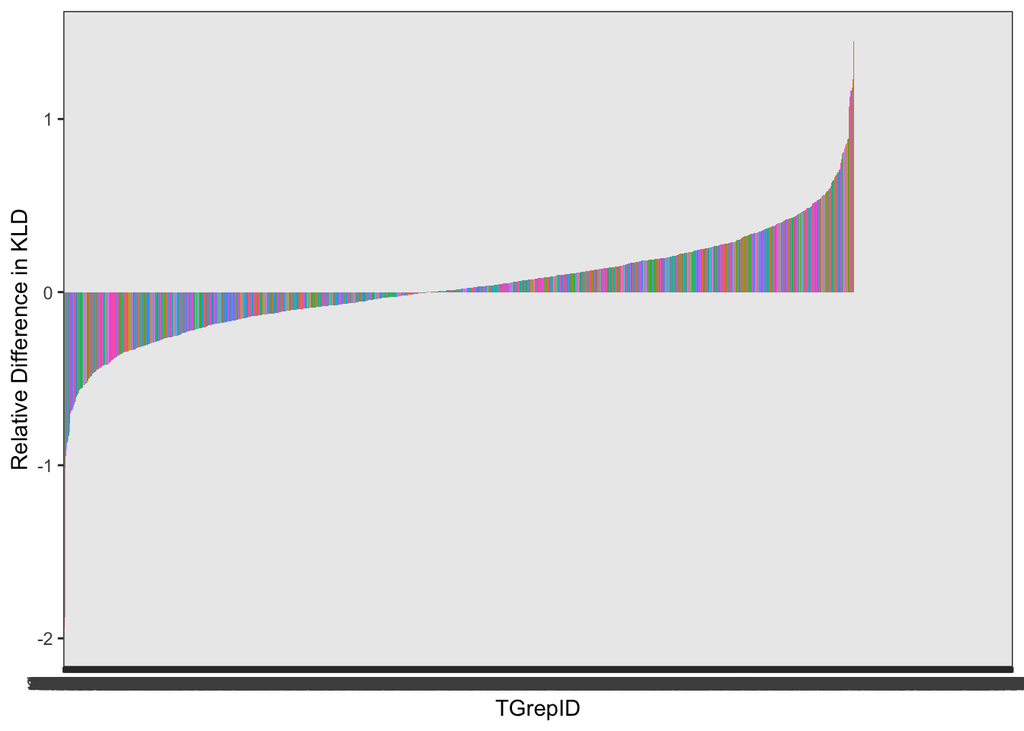

## High Positive difference

- 132917:4:what do you have *t*-1 now?
- the –> a/every

```
## # A tibble: 8 x 4
## # Groups:   Sentence, Task [2]
##   Sentence                    Task      paraphrase mean_rating
##   <chr>                       <chr>     <chr>            <dbl>
## 1 what do you have *t*-1 now? context   a             2.28e- 2
## 2 what do you have *t*-1 now? context   every         1.28e- 2
## 3 what do you have *t*-1 now? context   other         6.17e-18
## 4 what do you have *t*-1 now? context   the           9.64e- 1
## 5 what do you have *t*-1 now? nocontext a             2.41e- 1
## 6 what do you have *t*-1 now? nocontext every         2.54e- 1
## 7 what do you have *t*-1 now? nocontext other         4.28e- 2
## 8 what do you have *t*-1 now? nocontext the           4.62e- 1
```

- 89239:4:what was the last one *t*-1?
- the –> a/other

```
## # A tibble: 8 x 4
## # Groups:   Sentence, Task [2]
##   Sentence                     Task      paraphrase mean_rating
##   <chr>                        <chr>     <chr>            <dbl>
## 1 what was the last one *t*-1? context   a              0.00313
## 2 what was the last one *t*-1? context   every          0
## 3 what was the last one *t*-1? context   other          0
## 4 what was the last one *t*-1? context   the            0.997
## 5 what was the last one *t*-1? nocontext a              0.142
## 6 what was the last one *t*-1? nocontext every          0.0500
## 7 what was the last one *t*-1? nocontext other          0.165
## 8 what was the last one *t*-1? nocontext the            0.643
```

- 11053:4: where do you live *t*-1?
- the –> a/other

```
## # A tibble: 8 x 4
## # Groups:   Sentence, Task [2]
##   Sentence                 Task      paraphrase mean_rating
##   <chr>                    <chr>     <chr>            <dbl>
## 1 where do you live *t*-1? context   a                0
## 2 where do you live *t*-1? context   every            0
## 3 where do you live *t*-1? context   other            0.006
## 4 where do you live *t*-1? context   the              0.994
## 5 where do you live *t*-1? nocontext a                0.129
## 6 where do you live *t*-1? nocontext every            0.038
## 7 where do you live *t*-1? nocontext other            0.122
## 8 where do you live *t*-1? nocontext the              0.71
```

- 126136:4: how did radio shack work *t*-1?
- the –> the/a

```
## # A tibble: 8 x 4
## # Groups:   Sentence, Task [2]
##   Sentence                        Task      paraphrase mean_rating
##   <chr>                           <chr>     <chr>            <dbl>
## 1 how did radio shack work *t*-1? context   a               0.0333
## 2 how did radio shack work *t*-1? context   every           0.0783
## 3 how did radio shack work *t*-1? context   other           0.0189
## 4 how did radio shack work *t*-1? context   the             0.869
## 5 how did radio shack work *t*-1? nocontext a               0.263
## 6 how did radio shack work *t*-1? nocontext every           0.181
## 7 how did radio shack work *t*-1? nocontext other           0.168
## 8 how did radio shack work *t*-1? nocontext the             0.388
```

- 49447:4:what did you have *t*-1 before you bought that.
- the –> the/a

```
## # A tibble: 8 x 4
## # Groups:   Sentence, Task [2]
##   Sentence                                       Task     paraphrase mean_rating
##   <chr>                                          <chr>    <chr>            <dbl>
## 1 what did you have *t*-1 before you bought tha… context  a               0.0688
## 2 what did you have *t*-1 before you bought tha… context  every           0.0338
## 3 what did you have *t*-1 before you bought tha… context  other           0
## 4 what did you have *t*-1 before you bought tha… context  the             0.898
## 5 what did you have *t*-1 before you bought tha… noconte… a               0.290
## 6 what did you have *t*-1 before you bought tha… noconte… every           0.0729
## 7 what did you have *t*-1 before you bought tha… noconte… other           0.172
## 8 what did you have *t*-1 before you bought tha… noconte… the             0.465
```

## High Negative Difference

- 13656:19: uh, i have wondered why they allowed, or let, you know, both the father and mother go *t*-1, uh,
- the/every –> the

```
## # A tibble: 8 x 4
## # Groups:   Sentence, Task [2]
##   Sentence                                        Task    paraphrase mean_rating
##   <chr>                                           <chr>   <chr>            <dbl>
## 1 uh, i have wondered why they allowed, or let, … context a               0.095
## 2 uh, i have wondered why they allowed, or let, … context every           0.221
## 3 uh, i have wondered why they allowed, or let, … context other           0.0746
## 4 uh, i have wondered why they allowed, or let, … context the             0.609
## 5 uh, i have wondered why they allowed, or let, … nocont… a               0.0518
## 6 uh, i have wondered why they allowed, or let, … nocont… every           0.0176
## 7 uh, i have wondered why they allowed, or let, … nocont… other           0.0112
## 8 uh, i have wondered why they allowed, or let, … nocont… the             0.919
```

- 95676:26: if people will pay two hundred then why * charge ten *t*-1.
- the/a –> the

```
## # A tibble: 8 x 4
## # Groups:   Sentence, Task [2]
##   Sentence                                        Task    paraphrase mean_rating
##   <chr>                                           <chr>   <chr>            <dbl>
## 1 if people will pay two hundred then why * char… context a              0.221
## 2 if people will pay two hundred then why * char… context every          0.188
## 3 if people will pay two hundred then why * char… context other          0.15
## 4 if people will pay two hundred then why * char… context the            0.441
## 5 if people will pay two hundred then why * char… nocont… a              0.178
## 6 if people will pay two hundred then why * char… nocont… every          0.0553
## 7 if people will pay two hundred then why * char… nocont… other          0.00316
## 8 if people will pay two hundred then why * char… nocont… the            0.763
```

- 14478:20: so other than the vikings, who do you like *t*-1?
- a –> the

```
## # A tibble: 8 x 4
## # Groups:   Sentence, Task [2]
##   Sentence                                       Task     paraphrase mean_rating
##   <chr>                                          <chr>    <chr>            <dbl>
## 1 so other than the vikings, who do you like *t… context  a              0.317
## 2 so other than the vikings, who do you like *t… context  every          0.272
## 3 so other than the vikings, who do you like *t… context  other          0.225
## 4 so other than the vikings, who do you like *t… context  the            0.186
## 5 so other than the vikings, who do you like *t… noconte… a              0.234
## 6 so other than the vikings, who do you like *t… noconte… every          0.0489
## 7 so other than the vikings, who do you like *t… noconte… other          0.00842
## 8 so other than the vikings, who do you like *t… noconte… the            0.709
```

- 45111:93: whenever, the first time 0 i voted *t*-2, i never voted in high school because there was never anyone that *t*-1 showed us how * to use the voting machines *t*-3,
- the –> the, intennsifying

```
## # A tibble: 8 x 4
## # Groups:   Sentence, Task [2]
##   Sentence                                        Task    paraphrase mean_rating
##   <chr>                                           <chr>   <chr>            <dbl>
## 1 whenever, the first time 0 i voted *t*-2, i ne… context a               0.151
## 2 whenever, the first time 0 i voted *t*-2, i ne… context every           0.0534
## 3 whenever, the first time 0 i voted *t*-2, i ne… context other           0.158
## 4 whenever, the first time 0 i voted *t*-2, i ne… context the             0.638
## 5 whenever, the first time 0 i voted *t*-2, i ne… nocont… a               0.0626
## 6 whenever, the first time 0 i voted *t*-2, i ne… nocont… every           0.0542
## 7 whenever, the first time 0 i voted *t*-2, i ne… nocont… other           0
## 8 whenever, the first time 0 i voted *t*-2, i ne… nocont… the             0.883
```

- 142841:4: where do you think 0 they’re headed *t*-1,
- the/other –> the/a

```
## # A tibble: 8 x 4
## # Groups:   Sentence, Task [2]
##   Sentence                                   Task      paraphrase mean_rating
##   <chr>                                      <chr>     <chr>            <dbl>
## 1 where do you think 0 they're headed *t*-1, context   a               0.178
## 2 where do you think 0 they're headed *t*-1, context   every           0.0667
## 3 where do you think 0 they're headed *t*-1, context   other           0.302
## 4 where do you think 0 they're headed *t*-1, context   the             0.453
## 5 where do you think 0 they're headed *t*-1, nocontext a               0.143
## 6 where do you think 0 they're headed *t*-1, nocontext every           0.0238
## 7 where do you think 0 they're headed *t*-1, nocontext other           0.0256
## 8 where do you think 0 they're headed *t*-1, nocontext the             0.808
```

## Difference in KLD by factors

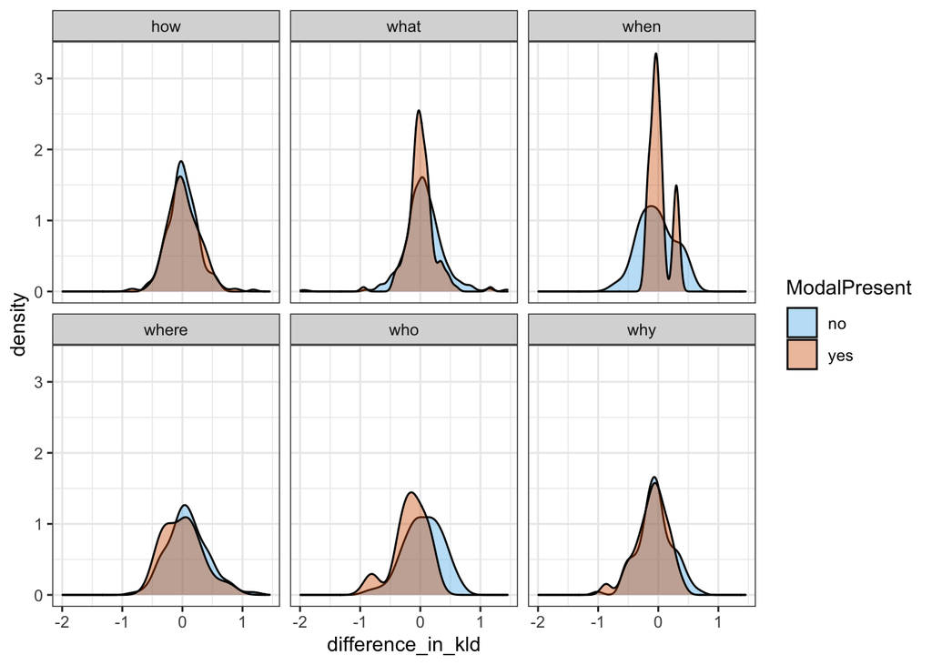

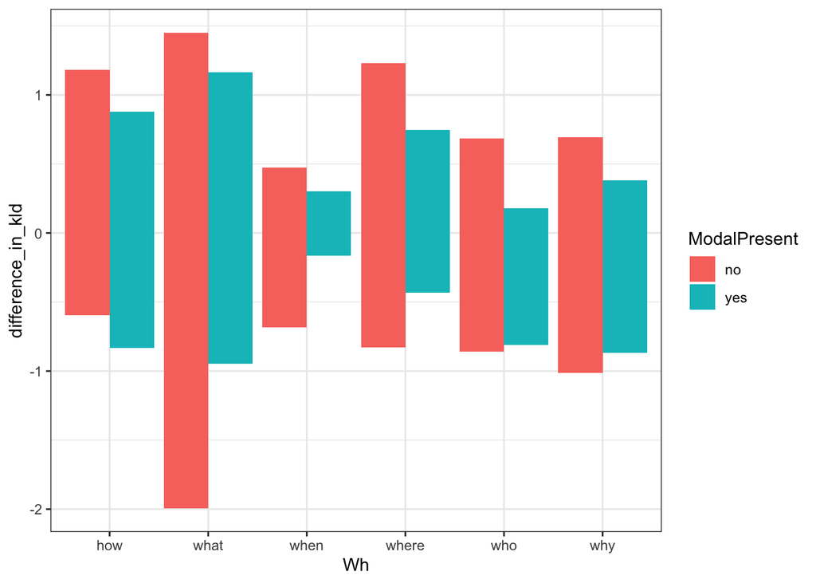

## Does Task predict KLD?

```
## Linear mixed model fit by REML. t-tests use Satterthwaite's method [
## lmerModLmerTest]
## Formula: kld ~ cTask + (1 | tgrep_id)
##    Data: d.kls
##
## REML criterion at convergence: 2007.8
##
## Scaled residuals:
##     Min      1Q  Median      3Q     Max
## -4.1853 -0.4769 -0.1130  0.3692  5.2035
##
## Random effects:
##  Groups   Name        Variance Std.Dev.
##  tgrep_id (Intercept) 0.09094  0.3016
##  Residual             0.04627  0.2151
## Number of obs: 3387, groups:  tgrep_id, 1848
##
## Fixed effects:
##               Estimate Std. Error         df t value Pr(>|t|)
## (Intercept)  4.632e-01  7.970e-03  1.828e+03  58.116  < 2e-16 ***
## cTask       -2.588e-02  7.626e-03  1.623e+03  -3.393 0.000707 ***
## ---
## Signif. codes:  0 '***' 0.001 '**' 0.01 '*' 0.05 '.' 0.1 ' ' 1
##
## Correlation of Fixed Effects:
##       (Intr)
## cTask 0.000
```

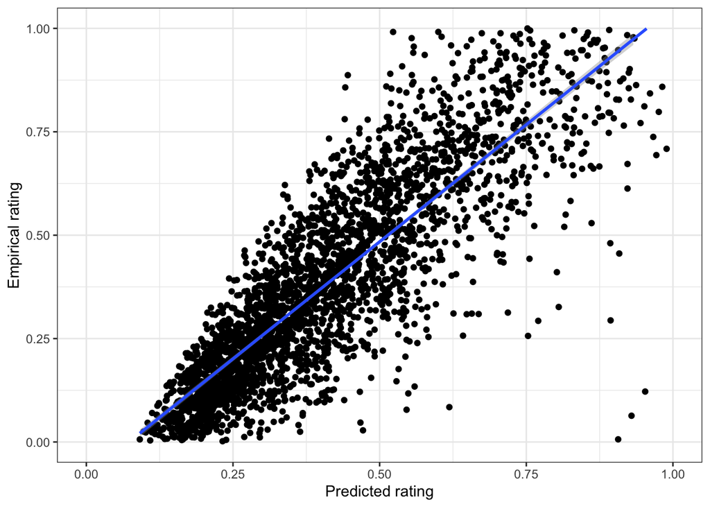

```
## [1] 0.9187154
```